# Smoking, Age, and Mortality: A Longitudinal Analysis of Whickham Data

### Exercises

1. What type of study do you think this data comes from: observational or experimental? Why?
2. How many observations are there in this dataset? What does each observation represent?
3. How many variables are in this dataset? What type of variable is each? Display each variable with an appropriate visualization.
4. What do you anticipate the relationship between smoking status and health outcome will be?
5. Create a visualization that shows the relationship between smoking status and health outcome. Briefly describe this relationship and assess whether it meets your expectations. Additionally, calculate the relevant conditional proportions to help your narrative.
6. Refer to the help page for the case_when() function from the dplyr package. Apply the case_when() function to create a new variable named age_cat in Whickham using this scheme:
- `age <= 44 ~ "18-44"`
- `age > 44 & age <= 64 ~ "45-64"`
- `age > 64 ~ "65+"`
7. Re-create the visualization showing the relationship between smoking status and health outcome, faceted by age_cat. What changed? What might explain this change?
8. Now use count() to calculate the conditional proportions from before, and this time break them down by age categories as well. Use this to support your narrative.

### Packages

We’ll use the **tidyverse** package for much of the data wrangling and visualization and the data lives in the **mosaicData** package.

install.packages(“mosaicData”)

You can load them by running the following in your Console:

```r
library(tidyverse)
library(mosaicData)
```

## Solutions

*Solution 1*. This is an observational study, because the researchers recorded existing behaviors (like smoking) and outcomes (alive/dead) without assigning treatments or interventions. No random assignment occurred.

*Solution 2*.

```r
nrow(Whickham)
```

```
[1] 1314
```

The dataset contains 1314 rows, and each observation represents one individual in the study, recording their smoking status, age and outcome (alive or dead).

*Solution 3*. The dataset contains three variables: age (numerical), smoker (categorical nominal), and outcome (categorical nominal).

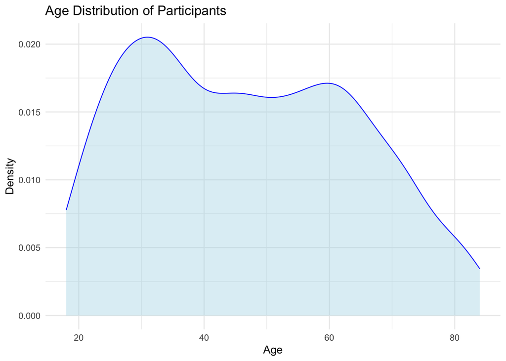

```r
# age:
ggplot(Whickham, aes(x = age)) +
  geom_density(color = "blue", linewidth = 0.4, fill = "lightblue", alpha = 0.4) +
  labs(
    title = "Age Distribution of Participants",
    x = "Age",
    y = "Density"
  ) +
  theme_minimal()
```

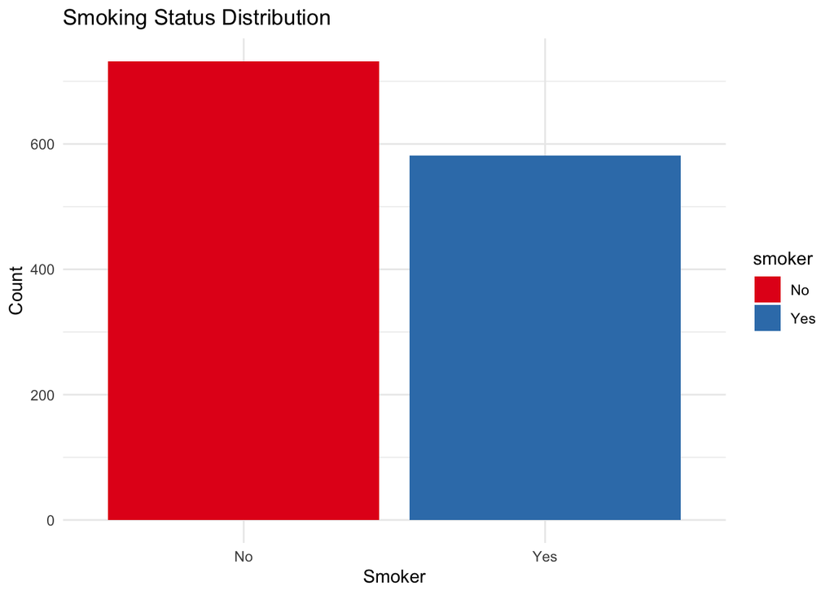

```r
# smoker:
ggplot(Whickham, aes(x = smoker, fill = smoker)) +
  geom_bar() +
  scale_fill_brewer(palette = "Set1") +
  labs(
    title = "Smoking Status Distribution",
    x = "Smoker",
    y = "Count"
  ) +
  theme_minimal()
```

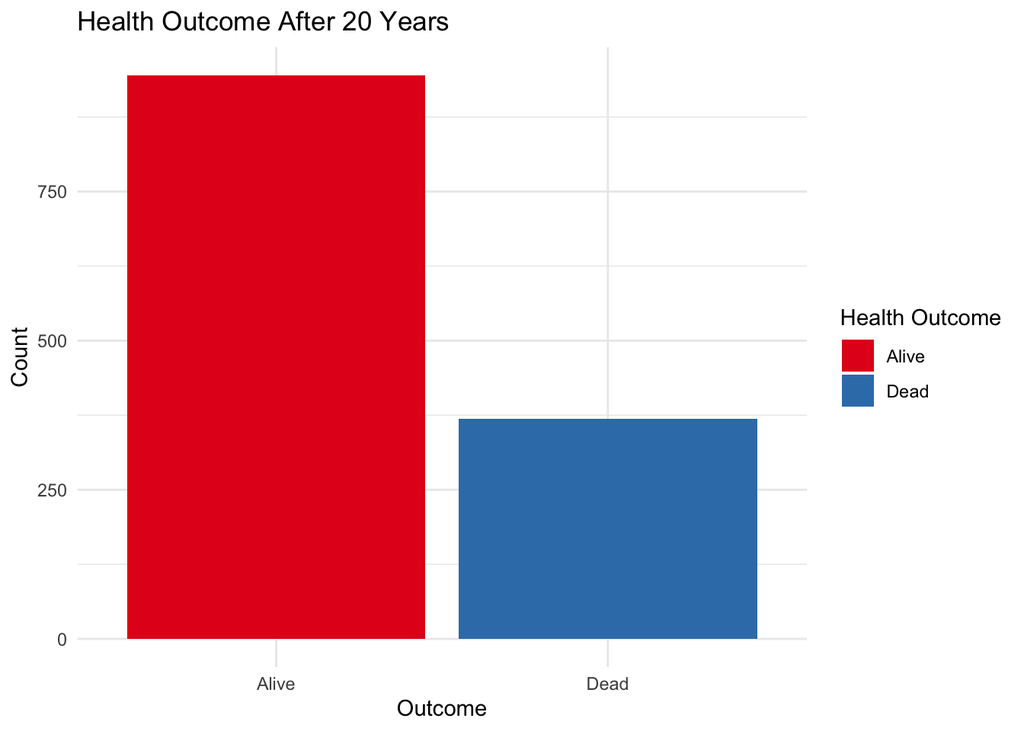

```r
# outcome:
ggplot(Whickham, aes(x = outcome, fill = outcome)) +
  geom_bar() +
  scale_fill_brewer(palette = "Set1") +
  labs(
    title = "Health Outcome After 20 Years",
    x = "Outcome",
    y = "Count",
    fill = "Health Outcome"
  ) +
  theme_minimal()
```

*Solution 4*. The expectation would be that smokers will have a higher proportion of deaths compared to non-smokers, since smoking is a known health risk.

*Solution 5*. We create a Filled Bar Chart.

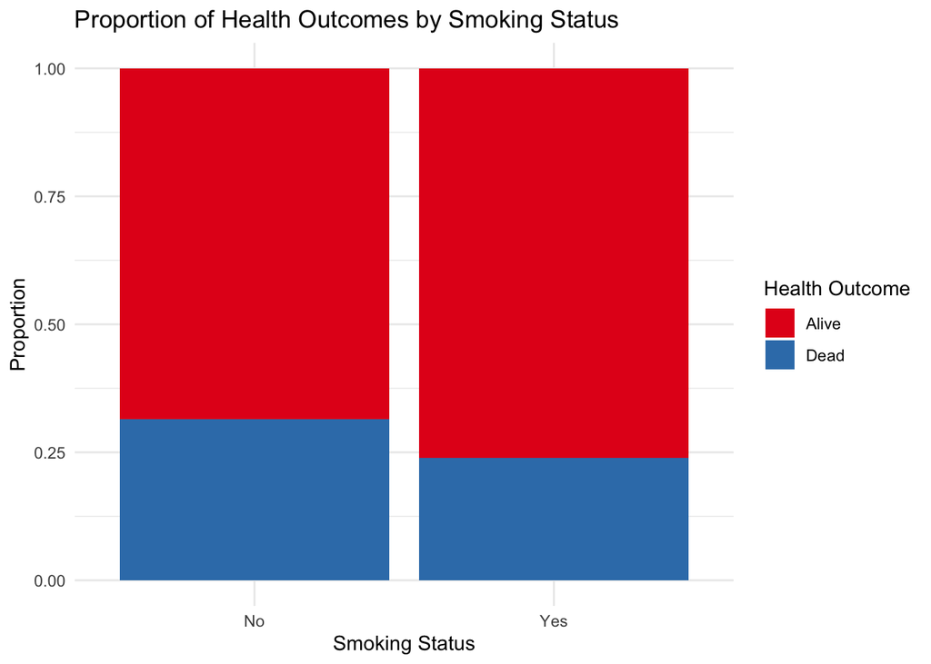

```r
Whickham |>
  ggplot(aes(x = smoker, fill = outcome)) +
  geom_bar(position = "fill") +
  scale_fill_brewer(palette = "Set1") +
  labs(
    title = "Proportion of Health Outcomes by Smoking Status",
    x = "Smoking Status",
    y = "Proportion",
    fill = "Health Outcome"
  ) +
  theme_minimal()
```

Description: From observing the proportion of outcomes within each smoking category, the data shows that smokers have a lower proportion of deaths and a higher proportion of survival compared to non-smokers.

We compute the conditional probabilities, which further confirm that smokers have a lower proportion of deaths and a higher proportion of survival (around 8%), compared to non-smokers—contrasting with our initial expectation.

```r
Whickham |>
  select(smoker, outcome) |>
  table() |>
  prop.table(margin = 1)
```

```
      outcome
smoker     Alive      Dead
   No  0.6857923 0.3142077
   Yes 0.7611684 0.2388316
```

*Solution 6*. We need to introduce a new variable to Whickham, so we will need to use `mutate()`.

```r
Whickham <- Whickham |>
  mutate(age_cat = case_when(
    age <= 44 ~ "18-44",
    age > 44 & age <= 64 ~ "45-64",
    age > 64 ~ "65+"
  ))

head(Whickham)
```

```
  outcome smoker age age_cat
1   Alive    Yes  23   18-44
2   Alive    Yes  18   18-44
3    Dead    Yes  71     65+
4   Alive     No  67     65+
5   Alive     No  64   45-64
6   Alive    Yes  38   18-44
```

*Solution 7*.

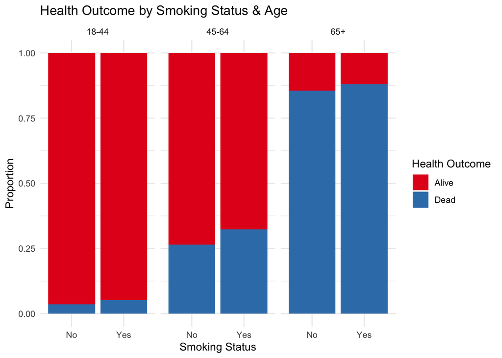

```r
Whickham |>
  ggplot(aes(x = smoker, fill = outcome)) +
  geom_bar(position = "fill") +
  facet_wrap(~ age_cat) +
  scale_fill_brewer(palette = "Set1") +
  labs(
    title = "Health Outcome by Smoking Status & Age",
    x = "Smoking Status",
    y = "Proportion",
    fill = "Health Outcome"
  ) +
  theme_minimal()
```

Faceting the plot by age_cat changes our initial interpretation: within each age group, smokers tend to have a higher proportion of deaths and a lower proportion of survival. The faceting helps reveal patterns that were previously masked by age differences in the overall population.

*Solution 8*.

```r
Whickham |>
  count(age_cat, smoker, outcome) |>
  group_by(age_cat, smoker) |>
  mutate(prop = n / sum(n))
```

```
# A tibble: 12 × 5
# Groups:   age_cat, smoker [6]
   age_cat smoker outcome     n   prop
   <chr>   <fct>  <fct>   <int>  <dbl>
 1 18-44   No     Alive     327 0.965
 2 18-44   No     Dead       12 0.0354
 3 18-44   Yes    Alive     270 0.947
 4 18-44   Yes    Dead       15 0.0526
 5 45-64   No     Alive     147 0.735
 6 45-64   No     Dead       53 0.265
 7 45-64   Yes    Alive     167 0.676
 8 45-64   Yes    Dead       80 0.324
 9 65+     No     Alive      28 0.145
10 65+     No     Dead      165 0.855
11 65+     Yes    Alive       6 0.12
12 65+     Yes    Dead       44 0.88
```

These conditional proportions confirm the trend revealed by faceting: within each age group, smokers have a higher proportion of deaths and a lower proportion of survival than non-smokers. This contradicts the misleading initial interpretation from the aggregated data, which is mainly influenced by the greater number of older individuals among non-smokers.